# Qualpal Alternatives

Johan Larsson

2026-10-12

## Background

Finding a good color palette for categorical data is a problem that has been tackled previously. In this vignette, we will compare the qualpal library with several alternatives, namely

- [Colorgorical](https://gramaz.io/colorgorical/)
- [Palletailor](https://www.yunhaiwang.net/infoVis2020/palettailor/color-palette-generation.html)
- [iWantHue](https://medialab.github.io/iwanthue/)
- [Distinctipy](https://distinctipy.readthedocs.io/en/latest/)
- [Glasbey](https://glasbey.readthedocs.io/en/latest/)

## iWantHue

[iWantHue](https://medialab.github.io/iwanthue/) served as the main inspiration for the qualpal package. It is a web-based (Javascript) tool that allows users to generate color palettes for categorical data. Like qualpal, it generates a set of points. But unlike qualpal, it uses a $k$-means clustering or force-vector algorithm to generate the final palette. It also only supports input in the LCH<sub>ab</sub> color space.

To compare the two, we will start by generating a palette with iWantHue. I used the web interface, but the Javascript code to generate the palette is as follows (which the app gratefully provides):

```javascript
var colors = paletteGenerator.generate(
  5, // Colors
  function(color){ // This function filters valid colors
    var hcl = color.hcl();
    return (hcl[0]>=50 || hcl[0]<=290)
      && hcl[1]>=0 && hcl[1]<=134
      && hcl[2]>=25 && hcl[2]<=85;
  },
  false, // Using Force Vector instead of k-Means
  50, // Steps (quality)
  false, // Ultra precision
  'Default' // Color distance type (colorblindness)
);
// Sort colors by differenciation first
colors = paletteGenerator.diffSort(colors, 'Default');
```

To compare the two, we now run `qualpal()` with same input.

```r
library(qualpalr)

hcl_space <- list(h = c(50, 290), c = c(0, 134), l = c(25, 85))
pal <- qualpal(n = 5, hcl_space)

pal
```

```
## ----------------------------------------
## Colors in the HSL color space
##
##      [,1] [,2] [,3]
## [1,]  210    1 0.50
## [2,]   14    1 0.23
## [3,]  120    1 0.17
## [4,]  162    1 0.50
## [5,]   25    1 0.72
##
##  ----------------------------------------
## DIN99d color difference distance matrix
##
##    1  2  3  4
## 2 31
## 3 29 24
## 4 29 36 26
## 5 31 24 28 27
```

Finally, to compare the two palettes, we can use the `analyze_palette()` function from **qualpalr**, which returns a list of analyses of the palettes, one for each type of color vision deficiency (CVD), with a configurable severity.

I’ve hard-coded the iWantHue palette here, and will compare it to the qualpal palette we just generated. Here, we show the color difference values for the normal vision analysis.

```r
iwanthue <- c(
  "#5f683c",
  "#5c87b5",
  "#79bf4b",
  "#c79041",
  "#7bb99d"
)

analyze_palette(pal$hex, metric = "ciede2000")$normal
```

```
## $difference_matrix
##          1        2        3        4
## 2 52.68595
## 3 60.31118 52.20662
## 4 55.50559 84.64856 51.73998
## 5 51.66201 51.61485 60.30675 51.91336
##
## $min_distances
##  #0081ff  #771b00  #005800  #00ffb1  #ffab71
## 51.66201 51.61485 51.73998 51.73998 51.61485
##
## $bg_min_distance
## [1] NaN
```

```r
analyze_palette(iwanthue, metric = "ciede2000")$normal
```

```
## $difference_matrix
##          1        2        3        4
## 2 40.29442
## 3 29.94464 50.43511
## 4 29.25577 42.50749 32.66864
## 5 29.76810 31.42995 17.49101 33.43658
##
## $min_distances
##  #5f683c  #5c87b5  #79bf4b  #c79041  #7bb99d
## 29.25577 31.42995 17.49101 29.25577 17.49101
##
## $bg_min_distance
## [1] NaN
```

The result shows a matrix of color differences for each color in the palette, as well as a vector of the minimum color difference for each color in the palette and a color difference with respect to the background (if used, which we did not in this case).

For a better visual comparison, we can plot the color difference values for each color in the palette.[^1]

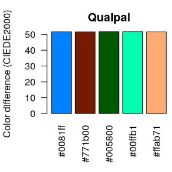

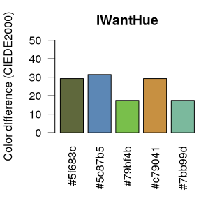

As you can see, qualpal produces a palette that’s much more distinct, with higher color difference values across the board.

Like qualpal, iWantHue also supports some adaptation for Color Vision Deficiency (CVD), but much less granular than qualpal. In fact I’m not sure how it works or what kind of CVD adaptation it supports.

## Colorgorical

[Colorgorical](https://gramaz.io/colorgorical/) is a web-based tool for generating color palettes for categorical data. It uses an iterative method with random sampling to incrementally build the palette. The algorithm is described in the paper by Gramazio et al. (2016).

It’s based on Python under the hood and the code is available [on GitHub](https://github.com/connorgr/colorgorical). The web app is, at the time of writing, down, but is otherwise accessible via a link on https://gramaz.io/colorgorical/. Prior to it going down, however, I generated a palette using the same HCL color space as for the iWantHue example above. By default, Colorgorical also tries to maximize the name difference of the colors, but I have turned that off for the sake of this comparison. The resulting palette is as follows:

```r
colorgorical <- c("#b4ddd4", "#9b233d", "#2eece6", "#f82387", "#32a190")
```

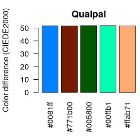

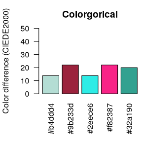

As before, we see that the qualpal palette is considerably more distinct.

## Glasbey

[Glasbey](https://glasbey.readthedocs.io/en/latest/) is a python library for generating color palettes for categorical data. It is based on academic work by Glasbey et al. (2007) and uses simulated annealing and the CIE76 metric to compute color differences. Here we used a slightly modified version of the colorspace above to generate a palette with 8 colors.

```python
import glasbey

pal = glasbey.create_palette(
    palette_size=8,
    hue_bounds=(-90, 90),
    chroma_bounds=(50, 100),
    lightness_bounds=(30, 70),
)
```

The resulting palette as well as the palette generated by qualpal are as follows:

```r
glasbey <- c(
  "#b20000",
  "#caa200",
  "#ff8ab2",
  "#aa145d",
  "#9e5d00",
  "#ff7910",
  "#ff008a",
  "#ca5d55"
)

pal2 <- qualpal(8, list(h = c(-90, 90), c = c(50, 100), l = c(30, 70)))
```

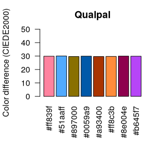

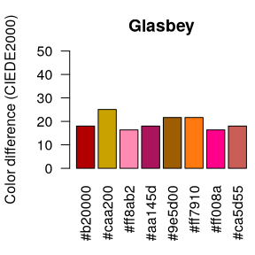

One option that’s shared by both qualpal and Glasbey is the possibility to extend an existing palette with more colors. Glasbey has a function for this, which we can use to extend a palette taken from the Glasbey documentation.

```python
base_pal = ["#2a3e63", "#7088b8", "#fcaf3e", "#b87088"]

pal_extend = glasbey.extend_palette(
    base_pal,
    palette_size=8,
    hue_bounds=(50,280),
    chroma_bounds=(50, 80),
    lightness_bounds=(25, 70),
)
```

To do this in qualpal, we can use the `extend` argument to `qualpal()`, which will extend the base palette.

```r
glasbey_extend <- c(
  "#2a3e63",
  "#7088b8",
  "#fcaf3e",
  "#b87088",
  "#417108",
  "#45dfa6",
  "#6d0c49",
  "#dfaaff"
)

base_pal <- c(
  "#2a3e63",
  "#7088b8",
  "#fcaf3e",
  "#b87088"
)

pal_extend <- qualpal(
  8,
  list(h = c(50, 280), c = c(50, 80), l = c(25, 70)),
  extend = base_pal
)
```

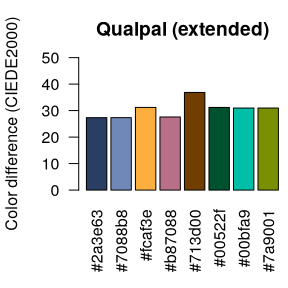

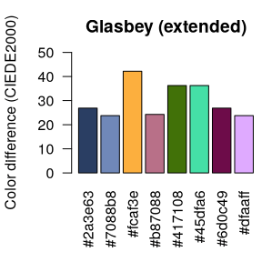

As in qualpal, glasbey also supports some adaptation for Color Vision Deficiency (CVD). Unlike qualpal, however, it only supports adaptation for a single type of CVD at a time, but also supports a severity parameter to control the strength of the adaptation.

We generated a palette with 6 colors, adapted for protanomaly with a severity of 100% (the maximum), using the following code:

```python
cvd_pal = glasbey.create_palette(
    palette_size=6,
    colorblind_safe=True,
    cvd_type="protanomaly",
    cvd_severity=100,
    hue_bounds=(50,280),
    chroma_bounds=(50, 80),
    lightness_bounds=(25, 70),
)
```

The resulting palette and the qualpal palette is given below.

```r
glasbey_cvd <- c(
  "#512deb",
  "#317d00",
  "#92d200",
  "#39ceff",
  "#00ba92",
  "#0082b2"
)

cvd_pal <- qualpal(
  6,
  list(h = c(50, 280), c = c(50, 80), l = c(25, 70)),
  cvd = c(protan = 1)
)
```

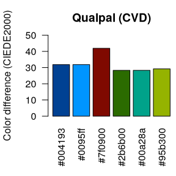

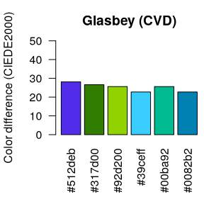

## Distinctipy

[Distinctipy](https://distinctipy.readthedocs.io/en/latest/) is another python library for generating color palettes for categorical data. It randomly samples colors from the RGB color space and then computes pairwise color differences with the CIE76 metric, repeats this for a set number of attempts, and then picks the best palette among the attempts.

I ran the following code to generate a 9-color palette with the default settings, included colors from all over the spectrum.[^2] There are no options other than a pastel color setting for changing this.

```python
import distinctipy

dpal = distinctipy.get_colors(9, rng = 0, n_attempts=1000)

[distinctipy.get_hex(c) for c in dpal]
```

```r
distinctipy <- c(
  "#cf02fd",
  "#00ff00",
  "#ff8000",
  "#01aced",
  "#0905c3",
  "#538337",
  "#80ff80",
  "#a80549",
  "#b28cd2"
)

pal3 <- qualpal(9, list(h = c(0, 360), s = c(0, 1), l = c(0, 1)))
```

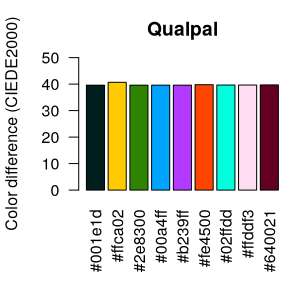

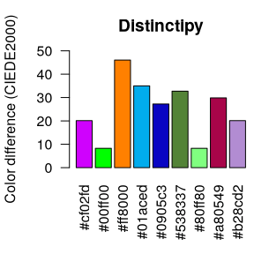

We see that qualpal produces a more distinct palette and that the palette from distinctipy is quite uneven, with two colors being very similar to each other.

## Palettailor

[Palettailor](https://www.yunhaiwang.net/infoVis2020/palettailor/color-palette-generation.html) is another web-based tool for generating color palettes for categorical data. It is based on academic work by Lu et al. (2021) and, like Glasbey, it uses a simulated annealing approach, albeit with the CIEDE2000 metric instead.

Compared to qualpal and the other alternatives here, it takes a different approach to generating color palettes. It optimizes the color palette for a specific plot design by trying to maximize the distinctiveness of the colors that are close to each other in the plot.For that reason, the comparisons here are not entirely fair, but if we turn off optimizations for name difference and point distinctiveness (in the web app), we can still compare the generated palette with qualpal.

```r
palettailor <- c(
  "#4ca600",
  "#5dfbbf",
  "#eda59f",
  "#32998d",
  "#605ec4",
  "#0099ef",
  "#e950e8",
  "#e1f32e",
  "#936411",
  "#e9003e"
)

hsl_space <- list(h = c(0, 360), s = c(0, 1), l = c(0.45, 0.95))
pal3 <- qualpal(10, hsl_space, bg = "white")
```

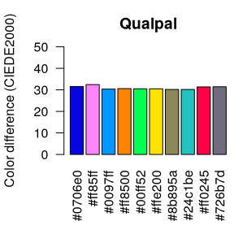

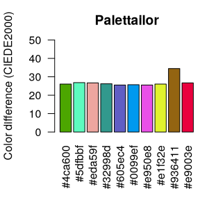

We again see that qualpal produces a more distinct palette, but this time the difference is not as pronounced as with the other alternatives.

## References

Glasbey, Chris, Gerie van der Heijden, Vivian F. K. Toh, and Alision Gray. 2007. “Colour Displays for Categorical Images.” *Color Research & Application* 32 (4): 304–9. https://doi.org/10.1002/col.20327.

Gramazio, Connor C., David H. Laidlaw, and Karen B. Schloss. 2016. “Colorgorical: Creating Discriminable and Preferable Color Palettes for Information Visualization.” *IEEE Transactions on Visualization and Computer Graphics* 23 (1): 521–30. https://doi.org/10.1109/TVCG.2016.2598918.

Lu, Kecheng, Mi Feng, Xin Chen, et al. 2021. “Palettailor: Discriminable Colorization for Categorical Data.” *IEEE Transactions on Visualization and Computer Graphics* 27 (02): 475–84. https://doi.org/10.1109/TVCG.2020.3030406.

[^1]: The code for these plots can be found in the source code of this vignette.
[^2]: There is only a pastels filter for limiting the colors.